# **Discovering**

## **Part-01**

The NOAA keeps a daily record of lightning strikes across much of North America.And we have tasked with performing EDA on this data setso that it can be used to predict future lightning strikes in this region.

### Overview

we will use pandas to examine 2018 lightning strike data collected by the National Oceanic and Atmospheric Administration (NOAA). Then, we will calculate the total number of strikes for each month and plot this information on a bar graph.

### Import packages and libraries

Before getting started, we will need to import all the required libraries and extensions. Throughout the course, we will be using pandas, numpy, and datetime for operations, and matplotlib, pyplot, and seaborn for plotting.

```python
import pandas as pd
import numpy as np
import datetime as dt
import matplotlib.pyplot as plt
%matplotlib inline
```

```python
#Read the dataset
df=pd.read_csv('./eda_using_basic_data_functions_in_python_dataset1.csv')
```

```python
#inspect the first 10 rows.
df.head(10)
```

|  | date | number_of_strikes | center_point_geom |
| --- | --- | --- | --- |
| 0 | 2018-01-03 | 194 | POINT(-75 27) |
| 1 | 2018-01-03 | 41 | POINT(-78.4 29) |
| 2 | 2018-01-03 | 33 | POINT(-73.9 27) |
| 3 | 2018-01-03 | 38 | POINT(-73.8 27) |
| 4 | 2018-01-03 | 92 | POINT(-79 28) |
| 5 | 2018-01-03 | 119 | POINT(-78 28) |
| 6 | 2018-01-03 | 35 | POINT(-79.3 28) |
| 7 | 2018-01-03 | 60 | POINT(-79.1 28) |
| 8 | 2018-01-03 | 41 | POINT(-78.7 28) |
| 9 | 2018-01-03 | 119 | POINT(-78.6 28) |

A quick way to determine how many rows and columns of data there are in total is to use df.shape. The information will be output as: ([rows],[columns]).

```python
df.shape
```

```
(3401012, 3)
```

```python
#Get more information about the data
df.info()
```

```
<class 'pandas.core.frame.DataFrame'>
RangeIndex: 3401012 entries, 0 to 3401011
Data columns (total 3 columns):
 #   Column             Dtype
---  ------             -----
 0   date               object
 1   number_of_strikes  int64
 2   center_point_geom  object
dtypes: int64(1), object(2)
memory usage: 77.8+ MB
```

### Convert the date column to datetime

As you see the date column data type is 'object' rather than 'date',objects are strings!. So date data type have additional functionality for dealing with date and time. So must convert it first.

```python
#Convert date column to date time
df['date']=pd.to_datetime(df['date'])
df.info()
```

```
<class 'pandas.core.frame.DataFrame'>
RangeIndex: 3401012 entries, 0 to 3401011
Data columns (total 3 columns):
 #   Column             Dtype
---  ------             -----
 0   date               datetime64[ns]
 1   number_of_strikes  int64
 2   center_point_geom  object
dtypes: datetime64[ns](1), int64(1), object(1)
memory usage: 77.8+ MB
```

### Calculate the days with the most strikes

As part of discovering, you want to get an idea of the highest data points. For this dataset, we can calculate the top 10 days of 2018 with the most number of lightning strikes using the `groupby()`, `sum()`, and `sort_values()` functions from pandas.

When using `groupby()` on the date column, the function combines all rows with the same date into a single row.

Then, using `sum()` performs a sum calculation on all other summable columns. In this case, we are summing all the lightning strikes that happened on each day. Notice that the `center_point_geom` column is not included in the output. That's because, as a string object, this column is not summable.

Finally, `sort_values()` returns the results in descending order of total strikes for each day in the data.

```python
#Calculate dates with most lightning strikes
df[['date','number_of_strikes']].groupby(['date']).sum().sort_values('number_of_strikes',ascending=False).reset_index().head(10)
```

|  | date | number_of_strikes |
| --- | --- | --- |
| 0 | 2018-08-29 | 1070457 |
| 1 | 2018-08-17 | 969774 |
| 2 | 2018-08-28 | 917199 |
| 3 | 2018-08-27 | 824589 |
| 4 | 2018-08-30 | 802170 |
| 5 | 2018-08-19 | 786225 |
| 6 | 2018-08-18 | 741180 |
| 7 | 2018-08-16 | 734475 |
| 8 | 2018-08-31 | 723624 |
| 9 | 2018-08-15 | 673455 |

### Extract the month data

```python
#Create a new 'month' column
df['month']=df['date'].dt.month
df.head()
```

|  | date | number_of_strikes | center_point_geom | month |
| --- | --- | --- | --- | --- |
| 0 | 2018-01-03 | 194 | POINT(-75 27) | 1 |
| 1 | 2018-01-03 | 41 | POINT(-78.4 29) | 1 |
| 2 | 2018-01-03 | 33 | POINT(-73.9 27) | 1 |
| 3 | 2018-01-03 | 38 | POINT(-73.8 27) | 1 |
| 4 | 2018-01-03 | 92 | POINT(-79 28) | 1 |

### Calculate the number of strikes per month

```python
#Calculate total number of strikes per month
df[['month','number_of_strikes']].groupby(['month']).sum().sort_values('number_of_strikes',ascending=False)
```

| month | number_of_strikes |
| --- | --- |
| 8 | 15525255 |
| 7 | 8320400 |
| 6 | 6445083 |
| 5 | 4166726 |
| 9 | 3018336 |
| 2 | 2071315 |
| 4 | 1524339 |
| 10 | 1093962 |
| 1 | 860045 |
| 3 | 854168 |
| 11 | 409263 |
| 12 | 312097 |

### Convert the month number to text

To help read the data more easily, let's convert the month number to text using the datetime function `dt.month_name()` and add this as a new column in the dataframe. `str.slice` will omit the text after the first three letters.

```python
#Create a new 'month_txt' column
df['month_txt']=df['date'].dt.month_name().str.slice(stop=3)
```

```python
df.head()
```

|  | date | number_of_strikes | center_point_geom | month | month_txt |
| --- | --- | --- | --- | --- | --- |
| 0 | 2018-01-03 | 194 | POINT(-75 27) | 1 | Jan |
| 1 | 2018-01-03 | 41 | POINT(-78.4 29) | 1 | Jan |
| 2 | 2018-01-03 | 33 | POINT(-73.9 27) | 1 | Jan |
| 3 | 2018-01-03 | 38 | POINT(-73.8 27) | 1 | Jan |
| 4 | 2018-01-03 | 92 | POINT(-79 28) | 1 | Jan |

### Create a new dataframe

The objective is to plot the total number of strikes per month as a bar graph.To help with the plotting, we will create a new dataframe called `df_by_month`.This will allow us to easily access the month,month text, and total number of strikes for each month.

```python
#Create a new helper dataframe for plotting.
df_by_month=df[['month','month_txt','number_of_strikes']].groupby(['month','month_txt']).sum().sort_values('month',ascending=True).reset_index()
```

```python
df_by_month
```

|  | month | month_txt | number_of_strikes |
| --- | --- | --- | --- |
| 0 | 1 | Jan | 860045 |
| 1 | 2 | Feb | 2071315 |
| 2 | 3 | Mar | 854168 |
| 3 | 4 | Apr | 1524339 |
| 4 | 5 | May | 4166726 |
| 5 | 6 | Jun | 6445083 |
| 6 | 7 | Jul | 8320400 |
| 7 | 8 | Aug | 15525255 |
| 8 | 9 | Sep | 3018336 |
| 9 | 10 | Oct | 1093962 |
| 10 | 11 | Nov | 409263 |
| 11 | 12 | Dec | 312097 |

### Make a bar chart

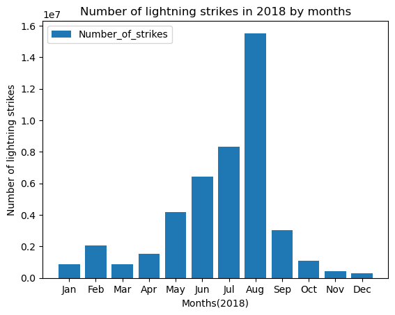

```python
plt.bar(x=df_by_month['month_txt'],
        height=df_by_month['number_of_strikes'],label='Number_of_strikes')
plt.xlabel("Months(2018)")
plt.ylabel("Number of lightning strikes")
plt.title("Number of lightning strikes in 2018 by months")
plt.legend()
plt.show()
```

## **Part-2**

the firm wants insights into unicorn companies–companies that are valued at over one billion dollars. The data you will use for this task provides information on over 1,000 unicorn companies, including their industry, country, year founded, and select investors. You will use this information to gain insights into how and when companies reach this prestigious milestone and to make recommentations for next steps to the investing firm.

```python
#Load the data frame
companies = pd.read_csv('./Unicorn_Companies.csv')
```

```python
companies.head()
```

|  | Company | Valuation | Date Joined | Industry | City | Country/Region | Continent | Year Founded | Funding | Select Investors |
| --- | --- | --- | --- | --- | --- | --- | --- | --- | --- | --- |
| 0 | Bytedance | $180B | 4/7/17 | Artificial intelligence | Beijing | China | Asia | 2012 | $8B | Sequoia Capital China, SIG Asia Investments, S... |
| 1 | SpaceX | $100B | 12/1/12 | Other | Hawthorne | United States | North America | 2002 | $7B | Founders Fund, Draper Fisher Jurvetson, Rothen... |
| 2 | SHEIN | $100B | 7/3/18 | E-commerce & direct-to-consumer | Shenzhen | China | Asia | 2008 | $2B | Tiger Global Management, Sequoia Capital China... |
| 3 | Stripe | $95B | 1/23/14 | Fintech | San Francisco | United States | North America | 2010 | $2B | Khosla Ventures, LowercaseCapital, capitalG |
| 4 | Klarna | $46B | 12/12/11 | Fintech | Stockholm | Sweden | Europe | 2005 | $4B | Institutional Venture Partners, Sequoia Capita... |

**Exploration through the result**

The "Date Joined" column represents when the company became a "unicorn" reaching one billion dollars in valuation.

The "Select Investors" column represent the top investors in the company.

### Assess the size of the data set

```python
companies.size
```

```
10740
```

### Get basic information about the dataset

```python
companies.info()
```

```
<class 'pandas.core.frame.DataFrame'>
RangeIndex: 1074 entries, 0 to 1073
Data columns (total 10 columns):
 #   Column            Non-Null Count  Dtype
---  ------            --------------  -----
 0   Company           1074 non-null   object
 1   Valuation         1074 non-null   object
 2   Date Joined       1074 non-null   object
 3   Industry          1074 non-null   object
 4   City              1058 non-null   object
 5   Country/Region    1074 non-null   object
 6   Continent         1074 non-null   object
 7   Year Founded      1074 non-null   int64
 8   Funding           1074 non-null   object
 9   Select Investors  1073 non-null   object
dtypes: int64(1), object(9)
memory usage: 84.0+ KB
```

**Exploration**

- Dtype is listed as int64 in the Year Founded column. This means that the year a company was founded is represented as an integer.
- Dtype is listed as object for the Date Joined column. This means that the date a company became a unicorn is represented as an object.

### Statistical tests

```python
#Get discriptive statistics
companies.describe()
```

|  | Year Founded |
| --- | --- |
| count | 1074.000000 |
| mean | 2012.895717 |
| std | 5.698573 |
| min | 1919.000000 |
| 25% | 2011.000000 |
| 50% | 2014.000000 |
| 75% | 2016.000000 |
| max | 2021.000000 |

### Convert the Date joined column Dtype to datetime data type

```python
companies['Date Joined']=pd.to_datetime(companies['Date Joined'])
```

```python
companies.info()
```

```
<class 'pandas.core.frame.DataFrame'>
RangeIndex: 1074 entries, 0 to 1073
Data columns (total 10 columns):
 #   Column            Non-Null Count  Dtype
---  ------            --------------  -----
 0   Company           1074 non-null   object
 1   Valuation         1074 non-null   object
 2   Date Joined       1074 non-null   datetime64[ns]
 3   Industry          1074 non-null   object
 4   City              1058 non-null   object
 5   Country/Region    1074 non-null   object
 6   Continent         1074 non-null   object
 7   Year Founded      1074 non-null   int64
 8   Funding           1074 non-null   object
 9   Select Investors  1073 non-null   object
dtypes: datetime64[ns](1), int64(1), object(8)
memory usage: 84.0+ KB
```

### Create a Year Joined column

```python
companies['Year Joined']=companies['Date Joined'].dt.year
```

```python
companies.head()
```

|  | Company | Valuation | Date Joined | Industry | City | Country/Region | Continent | Year Founded | Funding | Select Investors | Year Joined |
| --- | --- | --- | --- | --- | --- | --- | --- | --- | --- | --- | --- |
| 0 | Bytedance | $180B | 2017-04-07 | Artificial intelligence | Beijing | China | Asia | 2012 | $8B | Sequoia Capital China, SIG Asia Investments, S... | 2017 |
| 1 | SpaceX | $100B | 2012-12-01 | Other | Hawthorne | United States | North America | 2002 | $7B | Founders Fund, Draper Fisher Jurvetson, Rothen... | 2012 |
| 2 | SHEIN | $100B | 2018-07-03 | E-commerce & direct-to-consumer | Shenzhen | China | Asia | 2008 | $2B | Tiger Global Management, Sequoia Capital China... | 2018 |
| 3 | Stripe | $95B | 2014-01-23 | Fintech | San Francisco | United States | North America | 2010 | $2B | Khosla Ventures, LowercaseCapital, capitalG | 2014 |
| 4 | Klarna | $46B | 2011-12-12 | Fintech | Stockholm | Sweden | Europe | 2005 | $4B | Institutional Venture Partners, Sequoia Capita... | 2011 |

### Result and evaluation

#### Take sample of the data

It is not necessary to take a sample of the data in order to conduct the visualizations and EDA that follow. But you may encounter scenarios in the future where you will need to take a sample of the data due to time and resource limitations. For the purpose of developing your skills around sampling, take a sample of the data and work with that sample for the next steps of analysis you want to conduct. Use the `sample()` function for this task.

- Use `sample()` with the `n` parameter set to `50` to randomly sample 50 unicorn companies from the data. Be sure to specify the `random_state` parameter to ensure reproducibility of your work. Save the result to a variable called `companies_sampled`.

```python
#Sample the data
companies_sample=companies.sample(n=50,random_state=42)
```

### Visualize the time it took companies to reach unicorn status

```python
#Prepare data for plotting

#Create new `years_till_unicorn` column
companies_sample['years_till_unicorn']=companies_sample['Year Joined']-companies_sample['Year Founded']

#Group the data by `industry`. For each industry, get the max value in the `years_till_unicorn` column.
grouped =companies_sample[['Industry','years_till_unicorn']].groupby('Industry').sum().sort_values('years_till_unicorn',ascending=True).reset_index()
```

```python
grouped
```

|  | Industry | years_till_unicorn |
| --- | --- | --- |
| 0 | Consumer & retail | 1 |
| 1 | Auto & transportation | 2 |
| 2 | Artificial intelligence | 11 |
| 3 | Data management & analytics | 18 |
| 4 | Mobile & telecommunications | 21 |
| 5 | Cybersecurity | 23 |
| 6 | Other | 26 |
| 7 | Health | 32 |
| 8 | Supply chain, logistics, & delivery | 37 |
| 9 | E-commerce & direct-to-consumer | 38 |
| 10 | Fintech | 57 |
| 11 | Internet software & services | 95 |

[figure not shown]

```python
#Create the plot

plt.bar(grouped.Industry,grouped.years_till_unicorn)

#Set title
plt.title("Bar plot of maximum years taken by company to become unicorn per industry (from sample)")
#set x-axis label
plt.xlabel("Industry")
#set y-axis label
plt.ylabel("Maximum number of years")
#Rotate labels on the x-axis as a way to avoid overlap in the position of the text
plt.xticks(rotation=45,horizontalalignment='right')

plt.show()
```

### Visualize the maximum unicorn company valuation per industry

Visualize unicorn companies' maximum valuation for each industry represented in the sample. To create a bar plot to visualize this, use the `bar()` function from the `matplotlib.pyplot` module. Before plotting, create a new column that represents the companies' valuations as numbers (instead of strings, as they're currently represented). Then, use this new column to plot your data.

```python
# Create a column representing company valuation as numeric data

# Create new column
companies_sample['valuation_billions'] = companies_sample['Valuation']
# Remove the '$' from each value
companies_sample['valuation_billions'] = companies_sample['valuation_billions'].str.replace('$', '')
# Remove the 'B' from each value
companies_sample['valuation_billions'] = companies_sample['valuation_billions'].str.replace('B', '')
# Convert column to type int
companies_sample['valuation_billions'] = companies_sample['valuation_billions'].astype('int')
companies_sample.head()
```

|  | Company | Valuation | Date Joined | Industry | City | Country/Region | Continent | Year Founded | Funding | Select Investors | Year Joined | years_till_unicorn | valuation_billions |
| --- | --- | --- | --- | --- | --- | --- | --- | --- | --- | --- | --- | --- | --- |
| 542 | Aiven | $2B | 2021-10-18 | Internet software & services | Helsinki | Finland | Europe | 2016 | $210M | Institutional Venture Partners, Atomico, Early... | 2021 | 5 | 2 |
| 370 | Jusfoun Big Data | $2B | 2018-07-09 | Data management & analytics | Beijing | China | Asia | 2010 | $137M | Boxin Capital, DT Capital Partners, IDG Capital | 2018 | 8 | 2 |
| 307 | Innovaccer | $3B | 2021-02-19 | Health | San Francisco | United States | North America | 2014 | $379M | M12, WestBridge Capital, Lightspeed Venture Pa... | 2021 | 7 | 3 |
| 493 | Algolia | $2B | 2021-07-28 | Internet software & services | San Francisco | United States | North America | 2012 | $334M | Accel, Alven Capital, Storm Ventures | 2021 | 9 | 2 |
| 350 | SouChe Holdings | $3B | 2017-11-01 | E-commerce & direct-to-consumer | Hangzhou | China | Asia | 2012 | $1B | Morningside Ventures, Warburg Pincus, CreditEa... | 2017 | 5 | 3 |

```python
# Prepare data for modeling
grouped = (companies_sample[["Industry", "valuation_billions"]]
           .groupby("Industry")
           .max()
           .sort_values(by="valuation_billions")
          )
grouped
```

| Industry | valuation_billions |
| --- | --- |
| Auto & transportation | 1 |
| Consumer & retail | 1 |
| Other | 2 |
| Supply chain, logistics, & delivery | 2 |
| Cybersecurity | 3 |
| Health | 3 |
| Data management & analytics | 4 |
| E-commerce & direct-to-consumer | 4 |
| Internet software & services | 5 |
| Mobile & telecommunications | 7 |
| Fintech | 10 |
| Artificial intelligence | 12 |

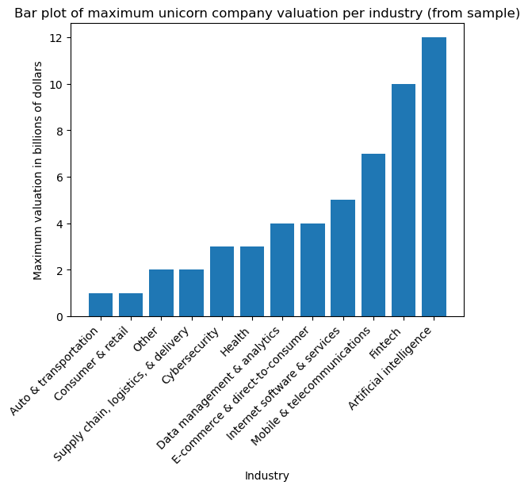

```python
# Create bar plot
# with Industry column as the categories of the bars
# and new valuation column as the heights of the bars

### YOUR CODE HERE ###

plt.bar(grouped.index, grouped["valuation_billions"])

# Set title

### YOUR CODE HERE ###

plt.title("Bar plot of maximum unicorn company valuation per industry (from sample)")

# Set x-axis label

### YOUR CODE HERE ###

plt.xlabel("Industry")

# Set y-axis label

### YOUR CODE HERE ###

plt.ylabel("Maximum valuation in billions of dollars")

# Rotate labels on the x-axis as a way to avoid overlap in the positions of the text

### YOUR CODE HERE ###

plt.xticks(rotation=45, horizontalalignment='right')

# Display the plot

### YOUR CODE HERE ###

plt.show()
```

- This bar plot shows that for this sample of unicorn companies, the highest maximum valuation occurred in the Artificial Intelligence industry, while the lowest maximum valuation occurred in the Auto & transportation, and Consumer & retail industries.

## Considerations

**What are some key takeaways that you learned from this ?**

**What findings would you share with others?**

- There are 1074 unicorn companies represented in this dataset.
- Some companies took longer to reach unicorn status but have accrued high valuation as of March 2022. Companies could take longer to achieve unicorn status for a number of reasons, including requiring more funding or taking longer to develop a business model.

**What recommendations would you share with stakeholders based on these findings?**

It may be helpful to focus more on industry specifics. Next steps to consider:

- Identify the main industries that the investing firm is interested in investing in.
- Select a subset of this data that includes only companies in those industries.
- Analyze that subset more closely. Determine which companies have higher valuation but do not have as many investors currently. They may be good candidates to consider investing in.

**References**

Bhat, M.A. (2022, March). [*Unicorn Companies*](https://www.kaggle.com/datasets/mysarahmadbhat/unicorn-companies).

Next >> (Date string manipulations with Python)